# Analysis of US Brewery Market

Brychan Manry and Patricia Goresen

October 23, 2017

```r
knitr::opts_chunk$set(echo = TRUE, message=FALSE)
library(dplyr)
library(kableExtra)
library(knitr)
library(ggplot2)
library(ggthemes)
library(tmap)
library(tmaptools)
library(grid)

# source custom functions
source("custom_functions.R")
```

# Introduction

The Company Hotshot Hops is creating a plan to expand their brewery across the nation. This analysis used datasets “beer.csv” and “breweries.csv” to look at different factors that determine the success Hopshot will have in each state.

## Ingest Data

```r
source("data_processing.R")
```

## Q1: How many breweries are present in each state?

#### **Reasoning:** More breweries means there will be more competition in that state.

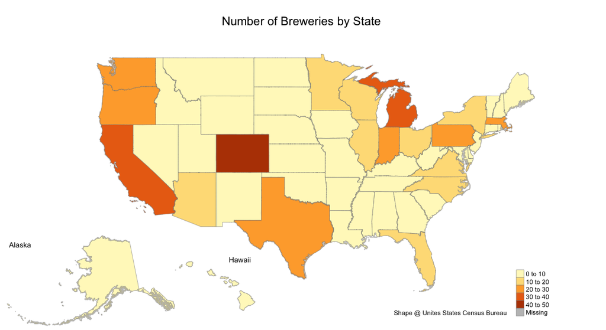

```r
usa.states.shape@data <- usa.states.shape@data %>%
  left_join(
    breweries %>% group_by(State) %>% summarise(n_breweries = n())
  )
makeMap(usa.states.shape,"n_breweries", "Number of Breweries by State")
```

The number of breweries in each state are shown in the table. The top five are Colorado with 47, California with 39, Michigan with 32, Oregon with 29 and Texas with 28. A full table of state brewery counts can be found at the bottom of this report

#### **Conclusion:** Since Colorado has the most breweries, we might not want to expand there.

## Q2: Merge data and print first and last six observations

```r
beers <- merge(beers, breweries, by.x = "Brewery_id", by.y = "Brew_ID")
head(beers, n=6)
```

```
##   Brewery_id     Beer_Name Beer_ID   ABV IBU
## 1          1  Get Together    2692 0.045  50
## 2          1 Maggie's Leap    2691 0.049  26
## 3          1    Wall's End    2690 0.048  19
## 4          1       Pumpion    2689 0.060  38
## 5          1    Stronghold    2688 0.060  25
## 6          1   Parapet ESB    2687 0.056  47
##                                 Style Ounces      Brewery_Name        City
## 1                        American IPA     16 NorthGate Brewing Minneapolis
## 2                  Milk / Sweet Stout     16 NorthGate Brewing Minneapolis
## 3                   English Brown Ale     16 NorthGate Brewing Minneapolis
## 4                         Pumpkin Ale     16 NorthGate Brewing Minneapolis
## 5                     American Porter     16 NorthGate Brewing Minneapolis
## 6 Extra Special / Strong Bitter (ESB)     16 NorthGate Brewing Minneapolis
##   State
## 1    MN
## 2    MN
## 3    MN
## 4    MN
## 5    MN
## 6    MN
```

```r
tail(beers,n=6)
```

```
##      Brewery_id                 Beer_Name Beer_ID   ABV IBU
## 2235        556             Pilsner Ukiah      98 0.055  NA
## 2236        557  Heinnieweisse Weissebier      52 0.049  NA
## 2237        557           Snapperhead IPA      51 0.068  NA
## 2238        557         Moo Thunder Stout      50 0.049  NA
## 2239        557         Porkslap Pale Ale      49 0.043  NA
## 2240        558 Urban Wilderness Pale Ale      30 0.049  NA
##                        Style Ounces                  Brewery_Name
## 2235         German Pilsener     12         Ukiah Brewing Company
## 2236              Hefeweizen     12       Butternuts Beer and Ale
## 2237            American IPA     12       Butternuts Beer and Ale
## 2238      Milk / Sweet Stout     12       Butternuts Beer and Ale
## 2239 American Pale Ale (APA)     12       Butternuts Beer and Ale
## 2240        English Pale Ale     12 Sleeping Lady Brewing Company
##               City State
## 2235         Ukiah    CA
## 2236 Garrattsville    NY
## 2237 Garrattsville    NY
## 2238 Garrattsville    NY
## 2239 Garrattsville    NY
## 2240     Anchorage    AK
```

The merged data is in a data frame called beers. The first six beers are Get Together, Maggie’s Leap, Wall’s End, Pumpion, Stronghold, and Parapet ESB. The last six beers are Pilsner Ukiah, Heinnieweisse Weissebier, Snapperhead IPA, Moo Thunder Stout, Porkslap Pale Ale, and Urban Wilderness Pale Ale.

## Q3: Report the number of NA’s in each column

```r
colSums(is.na(beers))
```

```
##   Brewery_id    Beer_Name      Beer_ID          ABV          IBU
##            0            0            0           62          973
##        Style       Ounces Brewery_Name         City        State
##            5            0            0            0            0
```

## Q4: Compute the median alcohol content and international bitterness unit for each state. Plot a bar chart to compare

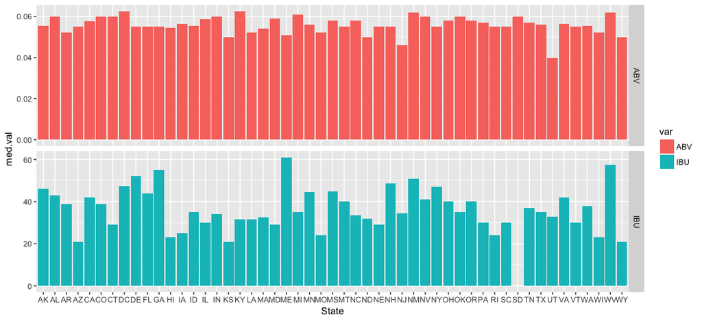

```r
# Median ABV and IBU by State Alpha
ggplot(
  bind_rows(
    beers %>% select(State, val = ABV) %>% mutate(var = "ABV"),
    beers %>% select(State, val = IBU) %>% mutate(var = "IBU")) %>%
    group_by(State, var) %>%
    summarise(med.val = median(val, na.rm = TRUE)),
  aes(x = State, fill = var, group = var)) +
  geom_bar(aes(y = med.val), stat = "identity",  position = "dodge") +
  facet_grid(var ~ ., scales = "free_y")
```

#### **ABV Reasoning:** A low median alcohol content could suggest there are strict state laws against brewing beers with higher alcohol content.

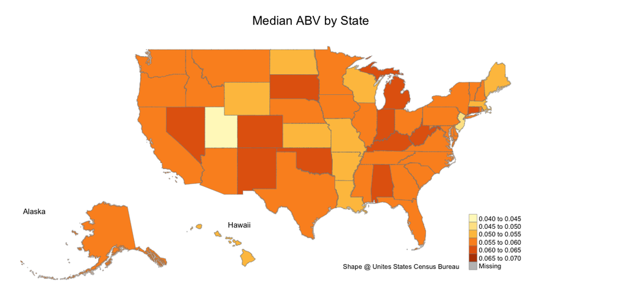

```r
usa.states.shape@data <- usa.states.shape@data %>%
  left_join(
    beers %>% group_by(State) %>% summarise(med_abv = median(ABV, na.rm = TRUE))
  )

makeMap(usa.states.shape, "med_abv", "Median ABV by State",seq(0.04,0.07,.005))
```

#### **IBU reasoning:** Our beer has a relatively high international bitterness unit, “IBU”. As a result, we want to expand in a state that is use to drinking beers with higher IBUs.

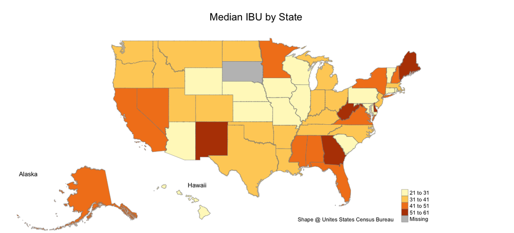

```r
usa.states.shape@data <- usa.states.shape@data %>%
  left_join(
    beers %>% group_by(State) %>% summarise(med_ibu = median(IBU, na.rm = TRUE))
  )
makeMap(usa.states.shape, "med_ibu", "Median IBU by State",seq(21,61,10))
```

## Q5: Which state has the maximum alcoholic beer? Which state has the most bitter beer?

#### **Reasoning for State’s median ABV and IBU:** Similiar to above, the state with the highest ABV is very unlikely to implement strict ABV laws. The state with the biggest median IBU means beers similiar to ours are present.

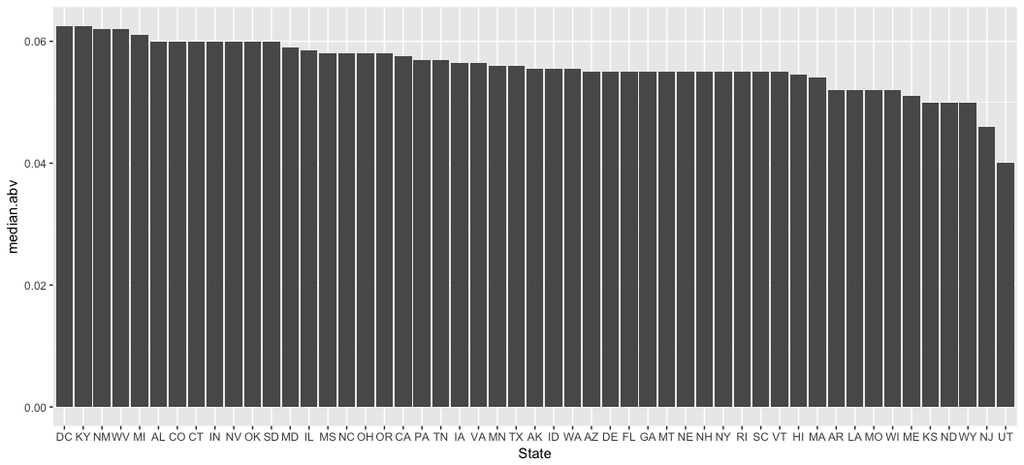

```r
# Median ABV by state - ordered by median
plot.df <- beers %>% group_by(State) %>% summarise(median.abv = median(ABV, na.rm = TRUE))
plot.df$State <- factor(plot.df$State, levels = plot.df$State[order(plot.df$median.abv, decreasing = TRUE)])
ggplot(plot.df, aes(State, y = median.abv)) + geom_bar(stat = "identity")
```

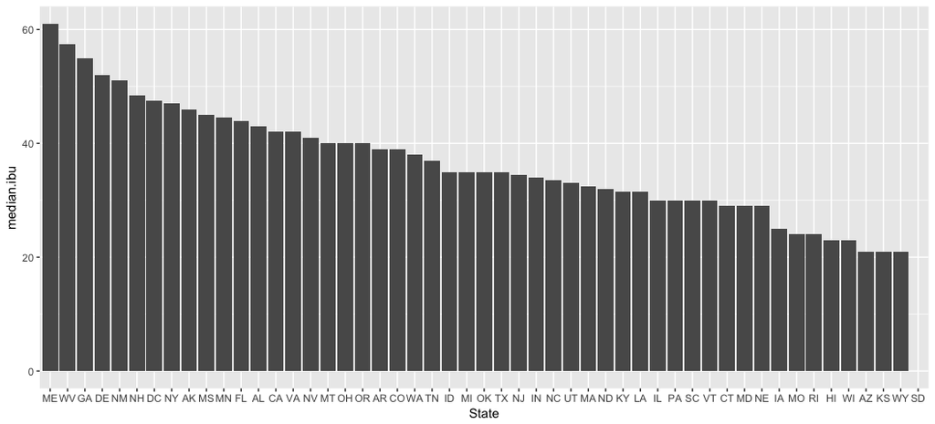

```r
# Median IBU by state - ordered by median
plot.df <- beers %>% group_by(State) %>% summarise(median.ibu = median(IBU, na.rm = TRUE))
plot.df$State <- factor(plot.df$State, levels = plot.df$State[order(plot.df$median.ibu, decreasing = TRUE)])
ggplot(plot.df, aes(State, y = median.ibu)) + geom_bar(stat = "identity")
```

#### **Conclusion for medians:** The states with the highest median ABV is the District of Columbia. The state with the largest IBU is Maine. Both of these States would be a match for our expansion.

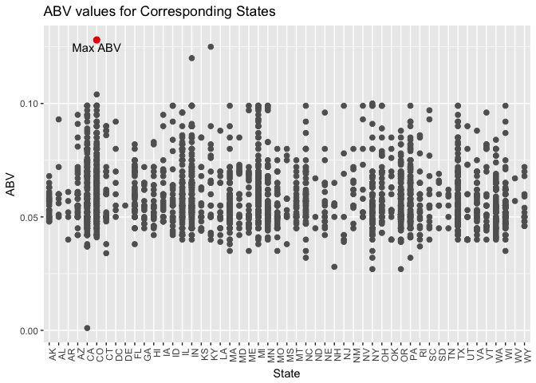

```r
#Maximum ABV of all States
MaxABV <- beers[which.max(beers$ABV),]
ggplot(beers, aes(x=State, y=ABV)) + geom_point(col="gray38", size=2) +geom_point(data=MaxABV, col="red2", size=2.5) + geom_text(data=MaxABV, label="Max ABV", vjust=1.4) + geom_segment(aes(x=State, xend= State, y=min(ABV), yend=max(ABV)), linetype="dashed", size=0.1) + labs(title= "ABV values for Corresponding States") + theme(axis.text.x=element_text(angle=90, hjust=1))
```

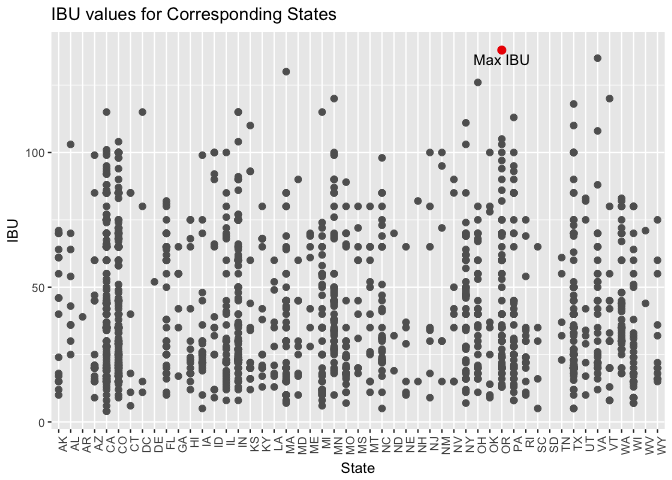

```r
#Maximum IBU of all States
MaxIBU <- beers[which.max(beers$IBU),]
ggplot(beers, aes(x=State, y=IBU)) + geom_point(col="gray38", size=2) +geom_point(data=MaxIBU, col="red2", size=2.5) + geom_text(data=MaxIBU, label="Max IBU", vjust=1.4) + geom_segment(aes(x=State, xend= State, y=min(IBU), yend=max(IBU)), linetype="dashed", size=0.1) + labs(title= "IBU values for Corresponding States") + theme(axis.text.x=element_text(angle=90, hjust=1))
```

#### **Conclusion for Max:** The state that has the maximum alcoholic beer is Colorado. The state that has the most bitter beer is Oregon. These would both be good matches based on our criteria.

## Q6: Summary statistics for the ABV

```r
summary(beers$ABV)
```

```
##    Min. 1st Qu.  Median    Mean 3rd Qu.    Max.    NA's
## 0.00100 0.05000 0.05600 0.05987 0.06800 0.12800      62
```

## Q7: Is there an apparent relationship between the bitterness of the beer and its alcoholic content?

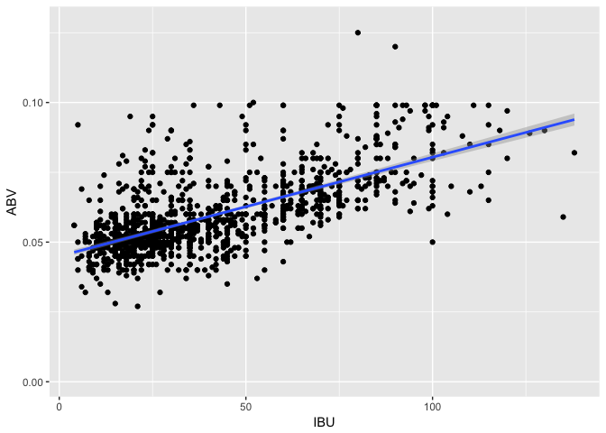

```r
ggplot(beers, aes(IBU, ABV))+
  geom_point() +
  geom_smooth(method = "lm")
```

```r
pander::pander(summary(lm(ABV ~ IBU, data = beers)))
```

|  | Estimate | Std. Error | t value | Pr(>\|t\|) |
| --- | --- | --- | --- | --- |
| **(Intercept)** | 0.04495 | 0.0005521 | 81.43 | 0 |
| **IBU** | 0.0003546 | 1.109e-05 | 31.98 | 6.111e-165 |

Fitting linear model: ABV ~ IBU

| Observations | Residual Std. Error | $R^2$ | Adjusted $R^2$ |
| --- | --- | --- | --- |
| 1267 | 0.01021 | 0.447 | 0.4466 |

## Appendix

### State Count Table

```r
as.data.frame(table(breweries$State), responseName = "Number of Breweries") %>% rename(State = Var1) %>% kable()
```

| State | Number.of.Breweries |
| --- | --- |
| AK | 7 |
| AL | 3 |
| AR | 2 |
| AZ | 11 |
| CA | 39 |
| CO | 47 |
| CT | 8 |
| DC | 1 |
| DE | 2 |
| FL | 15 |
| GA | 7 |
| HI | 4 |
| IA | 5 |
| ID | 5 |
| IL | 18 |
| IN | 22 |
| KS | 3 |
| KY | 4 |
| LA | 5 |
| MA | 22 |
| MD | 7 |
| ME | 9 |
| MI | 32 |
| MN | 11 |
| MO | 9 |
| MS | 2 |
| MT | 9 |
| NC | 19 |
| ND | 1 |
| NE | 5 |
| NH | 3 |
| NJ | 3 |
| NM | 4 |
| NV | 2 |
| NY | 16 |
| OH | 15 |
| OK | 6 |
| OR | 29 |
| PA | 25 |
| RI | 5 |
| SC | 4 |
| SD | 1 |
| TN | 3 |
| TX | 28 |
| UT | 4 |
| VA | 15 |
| VT | 9 |
| WA | 23 |
| WI | 19 |
| WV | 1 |
| WY | 4 |

### Link to Github Repository

[link] (https://github.com/bmanry13/case_study_1)